# main_file

Shiqi Duan

2017/11/29

This file is currently a template for implementing collaborative filtering algorithms. We implement the methods on a two datasets, Microsoft Web data, and EachMovie, provided by the project instructors. The two datasets are splited into a training set and d test set by the intructors.

## Step 0: Load the packages, specify directories

```r
packages.used=c("pROC","matrixStats","dplyr","lsa")
packages.needed=setdiff(packages.used, intersect(installed.packages()[,1], packages.used))
if(length(packages.needed)>0){
  install.packages(packages.needed, dependencies = TRUE)
}
library(pROC)
library(matrixStats)
library(dplyr)
library(lsa)
setwd("/Users/duanshiqi/Documents/GitHub/fall2017-project4-fall2017-proj4-grp6/doc")
# here replace it with your own path or manually set it in RStudio
# to where this rmd file is located
```

## Step 1: Load and process the data

For each record in the dataset, there are some information we want to extract and store them in a regular matrix form: users id in rows, items id in columns, and each element in the matrix represents the rating score. As the two original datasets are in different forms, we use two processing method to preprocess the two datasets.

```r
source("../lib/process.R")

process1 <- FALSE    # if TRUE, then process dataset1 in this main file
process2 <- FALSE    # if TRUE, then process dataset2 in this main file

# Prepocess dataset1
if(process1){
  train<-read.csv("../data/dataset1/data_train.csv", header = T)
  test<-read.csv("../data/dataset1/data_test.csv", header = T)
  train<-train[,-1]
  test<-test[,-1]
  ### convert data into matrix
  x<-train[train$V1=="V",]
  x<-x[order(x$V2),]
  attr<-unique(x$V2) # get all the attributes

  train_matrix<-process_dataset1(train)
  write.csv(train_matrix,"../output/dataset1_train.csv")
  test_matrix<-process_dataset1(test)
  write.csv(test_matrix,"../output/dataset1_test.csv")
}

# Prepocess dataset2

if(process2){
  train <- read.csv("../data/dataset2/data_train.csv",header=T)
  test<-read.csv("../data/dataset2/data_test.csv",header=T)
  movie <- unique(train$Movie)
  c <-length(movie)

  train_matrix <- process_dataset2(df = train)
  write.csv(train_matrix,"../output/dataset2_train.csv")
  test_matrix <- process_dataset2(df = test)
  write.csv(test_matrix,"../output/dataset2_test.csv")
}
# load processed dataset1
train1 <- read.csv("../output/dataset1_train.csv",header=T)
test1 <- read.csv("../output/dataset1_test.csv",header=T)
# load processed dataset2
train2 <- read.csv("../output/dataset2_train.csv",header=T)
test2 <- read.csv("../output/dataset2_test.csv",header=T)
```

## Step 2: Algorithm design

Algorithm1: Cluster Model

In Cluster Model, we only use it on dataset2, EachMovie. We assume there are C clusters and each user belongs to one cluster c. We use EM algorithm on training set to find the probability (mu) that each user belongs to a certain cluster and the probability (gamma) that in a certain cluster a user will rate a movie with a certain score. Then use the parameters mu and gamma to predict the scores in the test set. To determine the number of clusters to use in EM algorithm, we first run a 5-fold cross validation on the training set to get the cluster number with minimum cv-error.

```r
# load processed dataset2
#train2 <- read.csv("../output/dataset2_train.csv",header=T)
#test2 <- read.csv("../output/dataset2_test.csv",header=T)

rownames(train2) <- train2[,1]
train <- train2[,-1]
rownames(test2) <- test2[,1]
test <- test2[,-1]

M <- ncol(train)
N <- nrow(train)
movie <- colnames(train)
user <- rownames(train)

## functions on EM algorithm and Score Estimation based on results from EM
# EM
cluster_model <- function(df, C, tau){
  #Input: dataframe to train, number of classes, threshold to determine convergence
  #Output: parameters for cluster models:
  #        mu: probability of belonging to class c
  #        gamma: probability of scores for a movie given the class

  ## Step1: initialize the parameters
  set.seed(2)
  mu <- runif(C)
  mu <- mu/sum(mu)
  gamma <- array(NA,c(M,C,6)) #each list represents a class
  #the ijTh element means the probability of rating jth movie with score i in that class
  for(c in 1:C){
    for(m in 1:M){
      gamma[m,c,] <- runif(6)
      gamma[m,c,] <- gamma[m,c,]/sum(gamma[m,c,])
    }
  }

  w <- array(0, c(M,N,7))
  for(k in 1:6){
    w[,,k] <- ifelse(t(df)==k, 1, 0)
    w[,,k] <- ifelse(is.na(w[,,k]),0,w[,,k])
    w[,,7] <- w[,,7] + w[,,k]
  }

  mu_new <- mu
  gamma_new <- gamma
  #expect <- matrix(0, N, C) # expectation with rows meaning classes and columns meaning users

  ## Iterations based on the stop criterion
  threshold1 <- 9999
  threshold2 <- 9999
  threshold1_new <- 0
  threshold2_new <- 0
  count <- 0
  while((threshold1 > tau | threshold2 >tau)&(abs(threshold1-threshold1_new) > tau | abs(threshold2-threshold2_new) > tau)){
    count <- count + 1
    print(paste0("iteration = ", count))

    threshold1_new <- threshold1
    threshold2_new <- threshold2

    mu <- mu_new
    gamma <- gamma_new

    ## Step2: Expectation
    phi <- matrix(0, C, N)
    for(k in 1:6){
      phi <- phi + t(log(gamma[,,k]))%*%w[,,k]
    }
    phi <- phi-rep(colMeans(phi),each=C)

    for(c in 1:C){
      phi[c,] <- mu[c]*exp(phi)[c,]
    }
    phi <- ifelse(phi == rep(colSums(phi),each=C), 1, phi/rep(colSums(phi),each=C))

    ## Step3: Maximization
    mu_new <- rowSums(phi)/N  #update mu

    for(k in 1:6){
      gamma_new[,,k] <- w[,,k]%*%t(phi)/w[,,7]%*%t(phi) #update gamma
    }
    gamma_new[gamma_new == 0] <- 10^(-100)
    if(sum(is.na(gamma_new)) != 0){
      is_zero <- which(is.na(gamma_new))
      gamma_new[is_zero] <- rep(1/6, length(is_zero))
    }

    ## Check convergence
    threshold1 <- mean(abs(mu_new - mu)) #mean absolute difference of mu
    threshold2 <- 0
    for(c in 1:C){
      threshold2 <- max(threshold2,norm(as.matrix(gamma_new[,c,] - gamma[,c,]), "O"))# matrix 1-norm of the difference between updated and old gamma
    }
    print(paste0("threshold1 = ", threshold1, " threshold2 = ", threshold2))
  }
  return(list(mu = mu, gamma = gamma))
}

# Score Estimation
score_estimation_CM <- function(train_df, test_df, par){

  ###Input: dataframe of training set, test set, parameter list
  ###Output: estimated score
  set.seed(2)
  mu <- par$mu
  gamma <- par$gamma
  C <- length(mu)

  w <- array(0, c(M,N,7))
  for(k in 1:6){
    w[,,k] <- ifelse(t(train_df)==k, 1, 0)
    w[,,k] <- ifelse(is.na(w[,,k]),0,w[,,k])
  }
  w[,,7] <- ifelse(!is.na(t(test_df)), 1, 0)

  ##probability by Naive Bayes formula
  prob <- array(0,c(N,M,7))
  prob_mu <- matrix(mu, N, C, byrow = TRUE)
  phi <- matrix(0, C, N)
  for(k in 1:6){
    phi <- phi + t(log(gamma[,,k]))%*%w[,,k]
  }

  phi <- exp(phi)

  den <- matrix(diag(prob_mu%*%phi), N, M, byrow=FALSE)   #denominater in equation (2) of cluster model notes


  for(k in 1:6){
    print(paste0("k = ", k))

    num <- (t(phi)*prob_mu)%*%t(gamma[,,k]) #numerator in equation (2) of cluster model notes
    prob[,,k] <- ifelse(num==den & num == 0, runif(1)/6, num/den)
    prob[,,7] <- prob[,,7] + k*prob[,,k]
  }
  return(prob[,,7]*t(w[,,7]))
}

## 5-fold cross-validation
run.cm = FALSE #if TRUE, then run 5-fold cross-validation on training set of EachMovie
c_list <- c(2,3,6,12) #cluster numebrs we would like to try

if(run.cm){
  set.seed(2)
  K <- 5
  n <- ncol(train)
  n1 <- nrow(train)
  n.fold <- floor(n/K)
  n1.fold <- floor(n1/K)
  s <- sample(rep(1:K, c(rep(n.fold, K-1), n-(K-1)*n.fold)))
  s1 <- sample(rep(1:K, c(rep(n1.fold, K-1), n1-(K-1)*n1.fold)))

  validation_error <-  matrix(NA, K, length(c_list))

  train_df <- data.frame(matrix(NA, N, M))
  colnames(train_df) <- movie
  rownames(train_df) <- user

  test_df <- data.frame(matrix(NA, N, M))
  colnames(test_df) <- movie
  rownames(test_df) <- user

  for(i in 1:K){
    train_df[s1 != i, ] <- train[s1 != i, ]
    train_df[s1 == i, s != i] <- train[s1==i, s != i]
    test_df[s1 == i,s == i] <- train[s1 == i ,s == i]
    estimate_df <- test_df

    for(c in 1:length(c_list)){

      cm_par <- cluster_model(df = train_df, C = c_list[c], tau = 0.05)
      estimate_df <- score_estimation_CM(train_df = train_df, test_df = test_df, par = cm_par)
      validation_error[i,c] <- sum(abs(estimate_df-test_df),na.rm = T)/sum(!is.na(estimate_df-test_df))
  }
}
  save(validation_error, file=paste0("../output/validation_err.RData"))
  validation_error
}
if(!run.cm){
  load("../output/validation_err.RData")
  validation_error
}
```

```
##          [,1]     [,2]      [,3]     [,4]
## [1,] 1.027688 1.060630 0.9934067 1.049292
## [2,] 1.024357 1.046646 0.9970300 1.044445
## [3,] 1.032995 1.052055 1.0041185 1.049380
## [4,] 1.031121 1.049346 1.0030223 1.046118
## [5,] 1.019260 1.036678 0.9917086 1.035373
```

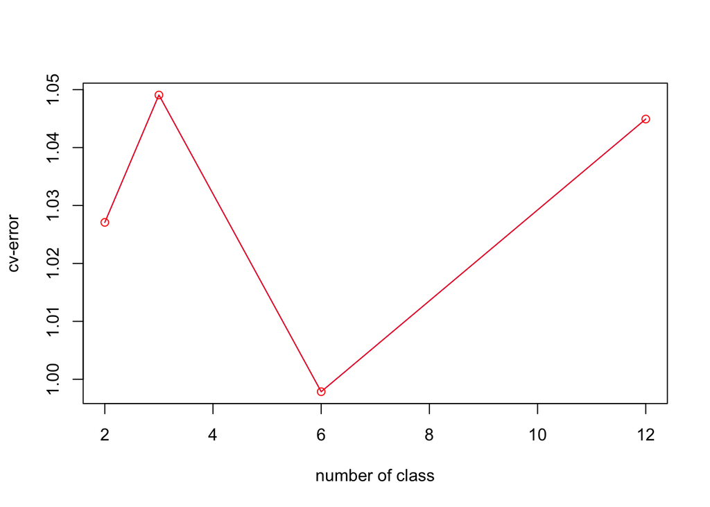

```r
# plot mean cv-error
cv_error<-colMeans(validation_error)
plot(c_list,cv_error,xlab="number of class",ylab="cv-error",col="blue",type="l")
points(c_list,cv_error,col="red",type="o")
```

```r
# find the best cluster number
class = c_list[which.min(cv_error)]
print(paste("Best class number is", class))
```

```
## [1] "Best class number is 6"
```

```r
# use best class number to find parameters in EM and predict the rates of movies in test set
run.best_par = FALSE #if TRUE, the rum the EM algorithm to find best parameters
if(run.best_par){
  best_par <- cluster_model(df = train, C = class, tau = 0.01)
  save(best_par, file=paste0("../output/best_par.RData"))
}else{
  load("../output/best_par.RData")
  best_par = best_par
}
estimate<-score_estimation_CM(train_df = train, test_df = test, par = best_par)
```

```
## [1] "k = 1"
## [1] "k = 2"
## [1] "k = 3"
## [1] "k = 4"
## [1] "k = 5"
## [1] "k = 6"
```

```r
# MAE of EM algorithm
error_em<- sum(abs(estimate-test),na.rm = T)/sum(!is.na(estimate-test))
print(paste0("THE MAE of cluster model is ", error_em))
```

```
## [1] "THE MAE of cluster model is 1.0087992212154"
```

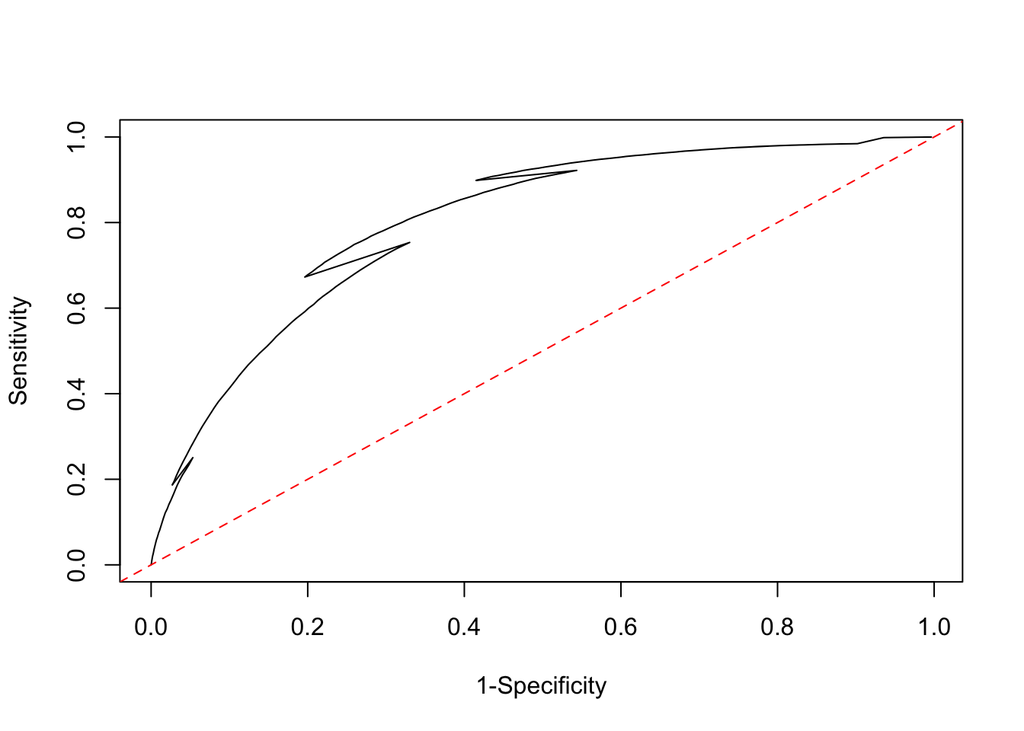

```r
# ROC of EM algorithm
run.emroc = FALSE #if TRUE, run specificity and sensitivity calculation for EM
if(run.emroc){
  threshold <- seq(1,6,by=0.02)
  sensitivity <- rep(0, length(threshold))
  specificity <- rep(0,length(threshold))
  for(i in 1:length(threshold)){
    print(paste("threshold = ", threshold[i]))
    t <- threshold[i]
    test_t <- ifelse(test>=t,1,0)
    estimate_t <- ifelse(estimate>=t,1,0)
    sensitivity[i] <- sum(test_t == 1 & estimate_t == 1, na.rm=T)/sum(test_t == 1, na.rm=T)
    specificity[i] <- sum(test_t == 0 & estimate_t == 0, na.rm=T)/sum(test_t == 0, na.rm=T)
  }
  save(sensitivity,file=paste("../output/em_sensitivity.RData"))
  save(specificity,file=paste("../output/em_specificity.RData"))
}else{
  load("../output/em_sensitivity.RData")
  load("../output/em_specificity.RData")
}
plot(1-specificity,sensitivity,xlab="1-Specificity",ylab="Sensitivity", type="l")
abline(0,1, col="red", lty=2)
```

```r
test_roc <- ifelse(test>=4,1,0)
estimate_roc <- ifelse(estimate>=4,1,0)
roc(as.vector(test_roc), as.vector(estimate_roc), na.rm = T)
```

```
##
## Call:
## roc.default(response = as.vector(test_roc), predictor = as.vector(estimate_roc),     na.rm = T)
##
## Data: as.vector(estimate_roc) in 68012 controls (as.vector(test_roc) 0) < 131864 cases (as.vector(test_roc) 1).
## Area under the curve: 0.7382
```

Algorithm2: Memory-based Algorithm In this Algorithm, there are four components we need to consider: Similarity Weight, Variance Weighting, Selecting Neighbors, and Rating Normalization.

Functions for Algorithm2

Similarity Weight: we use this to find the similarity correlation of different users

```r
# SW1: Spearman
spearman_weight <- function(matrix){
  file=deparse(substitute(matrix))
  file_name= paste0("./output/spearman_",file,".csv")

  matrix[is.na(matrix)] = 0
  matrix = t(matrix)
  w = cor(matrix,use="everything",method="spearman")

  write.csv(w,file=file_name)
}

# SW2: Vector Similarity
vector_similarity <- function(matrix){
  library(lsa)

  file=deparse(substitute(matrix))
  file_name= paste0("./output/vectorsimilarity_",file,".csv")

  matrix[is.na(matrix)] = 0
  matrix = t(matrix)
  w = cosine(matrix)
  write.csv(w,file=file_name)
}

# SW3: Mean Squared Difference
# Reduced the computational time significantly by assigning arguments outside
# the loops, initiating the output matrix r with NA first, and using apply
# to mean() outside the loops.
mean_sq_diff <- function(matrix){

  file=deparse(substitute(matrix))
  file_name= paste0("./output/meansqdiff_",file,".csv")

  matrix[is.na(matrix)] = 0
  usermean = apply(matrix,1,mean)

  ncolrow = nrow(matrix)
  w <- matrix(rep(NA), ncolrow, ncolrow)
  rownames(w) = rownames(matrix)
  colnames(w) = rownames(matrix)

  for (r in 1:ncolrow){
    for (c in 1:ncolrow){
      if (r>c){
        w[r,c] = w[c,r]
      }
      else if(r==c){
        w[r,c] = 0
      }
      else {
        w[r,c] = (usermean[r]-usermean[c])^2
      }
    }
  }
  write.csv(w,file=file_name)
}

## Calculate SW on datasets
rownames(train1) = train1[,1]
train1 = train1[,-1]
rownames(test1) = test1[,1]
test1 = test1[,-1]

rownames(train2) = train2[,1]
train2 = train2[,-1]
rownames(test2) = test2[,1]
test2 = test2[,-1]

run.sw1 = FALSE #If TURE run Spearman function on datasets
run.sw2 = FALSE #If TURE run vector similarity function on datasets
run.sw3 = FALSE #If TURE run mean squared difference function on datasets
if(run.sw1){
  w11 = spearman_weight(train1)
  w12 = spearman_weight(train2)
  write.cvs(w11,"../output/spearman_train1.csv")
  write.cvs(w12,"../output/spearman_train1.csv")
}
if(run.sw2){
  w21 = vector_similarity(train1)
  w22 = vector_similarity(train2)
  write.cvs(w21,"../output/vectorsimilarity_train1.csv")
  write.cvs(w22,"../output/vectorsimilarity_train2.csv")
}
if(run.sw3){
  w31 = mean_sq_diff(train1)
  w32 = mean_sq_diff(train2)
  write.csv(w31,"../output/meansqdiff_train1.csv")
  write.csv(w32,"../output/meansqdiff_train2.csv")
}

# SW4: SimRank, we only nedd this method for dataset1, Microsoft Web data
run.sw4 = FALSE #if TRUE, we are going to run the whole SimRank process for dataset1
if(run.sw4){
  # convert web name
  convert_colname <- function(dataset){
    names <- colnames(dataset)
    for(i in 1:ncol(dataset)){
      names[i] <- sub("X","",names[i])
    }
    return(names)
  }

  train_sm <- train1
  test_sm <- test1
  colnames(train_sm1) <- convert_colname(train_sm)
  colnames(test_sm1) <- convert_colname(test_sm)
  linkgraph_bip <- list()
  for(i in 1:nrow(train_sm)){
    linkgraph_bip[[i]] <- colnames(train_sm[i,])[which(train_sm[i,]==1)]
  }

  n = length(linkgraph_bip)

  t_train1 <- t(train_sm)
  t_train1 <- as.data.frame(t_train1)
  for(i in 1:nrow(t_train1)){
    linkgraph_bip[[n+i]] <- colnames(t_train1[i,])[which(t_train1[i,]==1)]
  }

  length(linkgraph_bip)
  nods_name <- as.numeric(c(rownames(train_sm),colnames(train_sm)))

  length <- c()
  for(i in 1:length(linkgraph_bip)){
    length[i] = length(linkgraph_bip[[i]])
  }

  max_len <- max(length)

  # Get graph matrix
  graph_matrix <- matrix(nrow = length(linkgraph_bip), ncol = max_len+1)
  graph_matrix[,1] <- nods_name

  for(i in 1:length(linkgraph_bip)){
    graph_matrix[i,2:(1+length(linkgraph_bip[[i]]))]<-as.numeric(linkgraph_bip[[i]])
  }

  dim(graph_matrix)

####################################### Simrank Algorithm #######################################

  graph <- graph_matrix

  nods<-nods_name
  nnods <- length(nods)

  trans_matrix <- function(graph){
    trans_matrix <- matrix(0, nrow = nnods, ncol = nnods)
    rownames(trans_matrix) <- nods
    colnames(trans_matrix) <- nods
    for(i in 1:nnods){
      n = sum(is.na(graph[i,-1])==F)
      for(m in 1:n){
        loc <- which(nods == graph[i,m+1])
        trans_matrix[i,loc] <- 1/n
      }
    }
    return(trans_matrix)
  }

  trans_matrix <- trans_matrix(graph)
  #write.csv(trans_matrix, file = "D:/Github/fall2017-project4-fall2017-proj4-grp6/output/trans.csv")

  #### naive method

  sim_matrix <- matrix(0, nrow = nnods, ncol = nnods)
  rownames(sim_matrix)<-nods
  colnames(sim_matrix)<-nods
  sim_matrix_old <- sim_matrix
  diag(sim_matrix) <- 1 # initial simrank matrix with diagnal = 1
  In <- sim_matrix

  c = 0.8
  niter = 5
  sim_list <- list()

  for(i in 1:niter){
    print(c("start",i))
    ptm <- proc.time()[1]
    sim_matrix_old <- sim_matrix
    sim_matrix <- c * (t(trans_matrix) %*% sim_matrix_old %*% trans_matrix) + (1-c)*In
    sim_list[[i]] <- sim_matrix
    end <- proc.time()[1]
    print(c("end", i, end-ptm))
  }


  simrank <- sim_list[[5]]
  simrank_matrix <- simrank[1:nrow(train1),1:nrow(train1)]
  # for easier upcoming calculation
  diag(simrank_matrix) <- 1
}
```

Variance Weighting: we use this to distinguish the items with high variance of rating. As variance weighting has to take use of the results of similarity weights, so we have different functions for each similarity weighting method.

```r
train2_vw <- train2
train2_vw[is.na(train2_vw)]<-0

run.vw1 = FALSE #if TRUE, run vector weighting algorithm on the datasets with Spearman
run.vw2 = FALSE #if TRUE, run vector weighting algorithm on the datasets with vector similarity
run.vw3 = FALSE #if TRUE, run vector weighting algorithm on the datasets with mean squared difference

# spearman
var_weighting_spearman <- function(matrix){
  var <- apply(matrix, 2, var)
  v <- (var-min(var))/max(var)
  matrix <- matrix * sqrt(v)
  spearman_vw <- cor(t(matrix), method = "spearman")
  return(spearman_vw)
}
if(run.vw1){
  spearman_vm_matrix1 <- var_weighting_spearman(train1)
  spearman_vm_matrix2 <- var_weighting_spearman(train2_vw)
  write.csv(vs_vw_matrix1,"../output/spearman_vm_train1.csv")
  write.csv(vs_vw_matrix2,"../output/spearman_vm_train2.csv")
}

# Vector Similarity
var_weighting_vecsim <- function(matrix){
  var <- apply(matrix, 2, var)
  v <- (var-min(var))/max(var)
  matrix <- matrix * sqrt(v)
  vs_vw <- cosine(t(matrix))
  return(vs_vw)
}
if(run.vw2){
  vs_vw_matrix1 <- var_weighting_vecsim(train1)
  vs_vw_matrix2 <- var_weighting_vecsim(train2_vw)
  write.csv(vs_vw_matrix1,"../output/vectorsimilarity_vm_train1.csv")
  write.csv(vs_vw_matrix2,"../output/vectorsimilarity_vm_train2.csv")
}

# mean squared difference
var_weighting_msd <- function(matrix){
  var <- apply(matrix, 2, var)
  v <- (var-min(var))/max(var)
  matrix <- matrix * sqrt(v)
  msd_vw <- mean_sq_diff(matrix)
  return(msd_vw)
}
if(run.vw3){
  msd_vm_matrix1 <- var_weighting_msd(train1)
  msd_vm_matrix2 <- var_weighting_msd(train2_vw)
}
```

Selecting Neighbors: we use this to select the users that are more similar to a certain user than others.

```r
train2_sn <- train2
train2_sn[is.na(train2_sn)]<-0
test2_sn <- test2
test2_sn[is.na(test2_sn)]<-0

run.sn <- FALSE #if TRUE, the run selecting neighbors algorithm on the results from above parts
if(run.sn){
  #### weight
  sp_w1 = read.csv("./output/spearman_train1.csv",header=T)
  sp_w2 = read.csv("./output/spearman_train2.csv",header=T)
  sp_vm_w1 = read.csv("./output/spearman_vm_train1.csv",header=T)
  sp_vm_w2 = read.csv("./output/spearman_vm_train1.csv",header=T)
  vs_w1 = read.csv("./output/vectorsimilarity_train1.csv",header=T)
  vs_w2 = read.csv("./output/vectorsimilarity_train1.csv",header=T)
  vs_vm_w1 = read.csv("./output/vectorsimilarity_vm_train1.csv",header=T)
  vs_vm_w2 = read.csv("./output/vectorsimilarity_vm_train2.csv",header=T)

  msd_w1 = read.csv("./output/meansqdiff_train1.csv",header=T)
  msd_w2 = read.csv("./output/meansqdiff_train2.csv",header=T)

  rownames(sp_w1) <- sp_w1[,1]
  sp_w1 <- sp_w1[,-1]

  rownames(sp_w2) <- sp_w2[,1]
  sp_w2 <- sp_w2[,-1]

  rownames(sp_vm_w1) <- sp_vm_w1[,1]
  sp_vm_w1 <- sp_vm_w1[,-1]

  rownames(sp_vm_w2) <- sp_vm_w2[,1]
  sp_vm_w2 <- sp_vm_w2[,-1]

  rownames(vs_w1) <- vs_w1[,1]
  vs_w1 <- vs_w1[,-1]

  rownames(vs_w2) <- vs_w2[,1]
  vs_w2 <- vs_w2[,-1]

  rownames(vs_vm_w1) <- vs_vm_w1[,1]
  vs_vm_w1 <- vs_vm_w1[,-1]

  rownames(vs_vm_w2) <- vs_vm_w2[,1]
  vs_vm_w2 <- vs_vm_w2[,-1]

  rownames(msd_w1) <- msd_w1[,1]
  msd_w1 <- msd_w1[,-1]

  rownames(msd_w2) <- msd_w2[,1]
  msd_w2 <- msd_w2[,-1]

  #### correlation-thresholding
  cor_threshold <- function(matrix, n){
    matrix_for_cal <- matrix
    matrix_for_cal[abs(matrix_for_cal) < n] <- NA
    diag(matrix_for_cal) <- NA
    cor_thre <- list()
    for(i in 1:nrow(matrix_for_cal)){
      x <- matrix_for_cal[i,]
      cor_thre[[i]] <- which(is.na(x)==F)
      print(i) # To see the process
    }
    return(cor_thre)
  }
  #### best-n-neighbors
  bestnn <- function(matrix, nnbors){
    best <- list()
    for(i in 1:nrow(matrix)){
      best[[i]] <- order(matrix[i,], decreasing = T)[2:(nnbors+1)]
      print(i)
    }
    return(best)
  }
  # you can try different files into the function here, this is just an example
  bnnbors <- bestnn(spearman_matrix1, 30) # nnbors = 30

  #### combined
  list1 = bestnn(matrix, nnbors)
  list2 = cor_threshold(matrix, n)

  combined <- function(matrix){
    bnn = list1
    thresh = list2
    combine <- list()
    for(i in 1:nrow(matrix)){
      combine[[i]] <- unique(c(bnn[[i]],thresh[[i]]))
    }
    return(combine)
  }
}
```

Rating Normalization: we use Z-score to predict scores in this component.

```r
z_score<-function(df, w, neighbor_matrix){
  #Input: Rating dataset with users in row and items in columns, Weight matrix between users
  #Output: Prediction matrix with users in row and items in columns
  N <- nrow(df)
  M <- ncol(df)

  df_mean <- matrix(rep(rowMeans(df), M), N, M)
  df_sd <- matrix(rep(rowSds(as.matrix(df)), M), N, M)
  w_new <- neighbor_matrix * w
  w_sum <- matrix(rep(rowSums(w_new), M), N, M)
  df_scale <- (df - df_mean)/df_sd
  p <- df_sd * t((t(df_scale) %*% as.matrix(w_new)))/w_sum
  return(p + df_mean)
}
```

## Step 3: Evaluation

```r
# Ranked Scoring
randked_scoring <- function(pred_matrix, observed_matrix){
  nrow = nrow(pred_matrix)
  ncol = ncol(pred_matrix)
  a_minus_one = nrow/2 - 1

  # rank/sort pred_matrix by vote value. Assuming d=0 here.
  numerator_matrix = t(apply(pred_matrix, 1, sort,decreasing=T))

  # denominator of r_a
  denom_vector = rep(NA, ncol)
  for (j in 1:ncol){
    denom_vector[j] <- 2^((j-1)/a_minus_one)
  }

  # get a vector of r_a
  utility_matrix = numerator_matrix %*% diag(1 / denom_vector)
  r_a_vector = rowSums(utility_matrix)

  # get a r_a_max value
  max_numerator_matrix = t(apply(observed_matrix, 1, sort,decreasing=T))
  max_utility_matrix = max_numerator_matrix %*% diag(1 / denom_vector)
  max_r_a_vector = rowSums(max_utility_matrix)

  # Get the r_a / r_a_max score
  r = 100 * sum(r_a_vector)/sum(max_r_a_vector)

  return(r)
}

# MAE
MAE <- function(pred, test){
  out = sum(abs(pred - test))/sum(test != 0)
  return(out)
}
```

When doing the evaluation, to compare different variants in each component, we read the recommended papers first. From the papers, we learn that Spearman should be better than vector similarity weighting and mean squared difference weighting, taking variance weighting will not make more significant contribution to the results, and the combination of weight-threshold and best-b-estimator will not be better than using only one selecting neighbor method from these two. However, we do not find evidence from papers whether SimRank is better than Spearman or not, nor which one of weight-threshold and best_n_neighbor is better than the other. So for dataset2 we just used Spearman and no variance weighting when comparing selecting neighbor methods(by ROC results). Then we get the best selecting neighbor methods, best_n_neighbor, and use it to compare variants in other components. For dataset1, we used no variance weighting and best_n_neighbor(based on paper and our results from dataset2) to compare similarity weighting methods and get the best similarity weighting method. Then use it while comparing variants in other components. ## Step 4: Results and Conclusions

```r
results<-read.table("/Users/duanshiqi/Desktop/results.txt",header=T)
results
```

```
##    Dataset       Similarity_Weight Variance_Weighting Selecting_Neighbor
## 1        2                Spearman                 no   weight_threshold
## 2        2                Spearman                 no    best_n_neighbor
## 3        2                Spearman                 no           combined
## 4        2                Spearman                yes    best_n_neighbor
## 5        2       vector_similarity                 no    best_n_neighbor
## 6        2 mean_squared_difference                 no    best_n_neighbor
## 7        2           cluster_model               <NA>               <NA>
## 8        1                Spearman                 no    best_n_neighbor
## 9        1       vector_similarity                 no    best_n_neighbor
## 10       1 mean_squared_difference                 no    best_n_neighbor
## 11       1                 SimRank                 no    best_n_neighbor
## 12       1                Spearman                yes    best_n_neighbor
## 13       1                Spearman                 no    best_n_neighbor
## 14       1                Spearman                 no    best_n_neighbor
```

[output cut: 19 more lines]